# housing prices

James(Changhwan) Han (3923257)

6/2/2022

# Introduction

The purpose of this project is to generate a model that will predict the median housing prices for California districts.

# About Dataset

The data contains median house prices for California districts derived from the 1990 census.  
Obtained from Kaggle, https://www.kaggle.com/datasets/camnugent/california-housing-prices, the data includes 20640 observations and 9 predictors; longitude, latitude, housing_median_age, total_rooms, total_bedrooms, population, households, median_income, and ocean_proximity.  
There are 207 missing values in total_bedrooms column.

# Loading Data and Packages

Here are some of the key variables that are helpful for this project, the codebook is also included in the zipped files.  
1. longitude: A measure of how far west a house is; a higher value is farther west  
2. latitude: A measure of how far north a house is; a higher value is farther north  
3. housingMedianAge: Median age of a house within a block; a lower number is a newer building  
4. totalRooms: Total # of rooms within a block  
5. totalBedrooms: Total # of bedrooms within a block  
6. population: Total # of people residing within a block  
7. households: Total # of households, a group of people residing within a home unit, for a block  
8. medianIncome: Median income for households within a block of houses (measured in tens of thousands of US Dollars)  
9. medianHouseValue: Median house value for households within a block (measured in US Dollars)  
10. oceanProximity: Location of the house with reference to ocean/sea

```r
# load packages
library("janitor")
library(tidymodels)
library(tidyverse)
library(corrplot)
library(png)
library(grid)
tidymodels_prefer()
library(kknn)
library(kernlab)
library(rlang)
library(knitr)
library(discrim)
library(klaR)
library(glmnet)
library(rpart.plot)
library(ranger)
library(vip)

# set seed
set.seed(1014)
```

```r
# read in data
housing <- read_csv("housing.csv")
```

# Data Cleaning

```r
head(housing)
```

```
## # A tibble: 6 x 10
##   longitude latitude housing_median_age total_rooms total_bedrooms population
##       <dbl>    <dbl>              <dbl>       <dbl>          <dbl>      <dbl>
## 1     -122.     37.9                 41         880            129        322
## 2     -122.     37.9                 21        7099           1106       2401
## 3     -122.     37.8                 52        1467            190        496
## 4     -122.     37.8                 52        1274            235        558
## 5     -122.     37.8                 52        1627            280        565
## 6     -122.     37.8                 52         919            213        413
## # ... with 4 more variables: households <dbl>, median_income <dbl>,
## #   median_house_value <dbl>, ocean_proximity <chr>
```

```r
summary(housing)
```

```
##    longitude         latitude     housing_median_age  total_rooms
##  Min.   :-124.3   Min.   :32.54   Min.   : 1.00      Min.   :    2
##  1st Qu.:-121.8   1st Qu.:33.93   1st Qu.:18.00      1st Qu.: 1448
##  Median :-118.5   Median :34.26   Median :29.00      Median : 2127
##  Mean   :-119.6   Mean   :35.63   Mean   :28.64      Mean   : 2636
##  3rd Qu.:-118.0   3rd Qu.:37.71   3rd Qu.:37.00      3rd Qu.: 3148
##  Max.   :-114.3   Max.   :41.95   Max.   :52.00      Max.   :39320
##
##  total_bedrooms     population      households     median_income
##  Min.   :   1.0   Min.   :    3   Min.   :   1.0   Min.   : 0.4999
##  1st Qu.: 296.0   1st Qu.:  787   1st Qu.: 280.0   1st Qu.: 2.5634
##  Median : 435.0   Median : 1166   Median : 409.0   Median : 3.5348
##  Mean   : 537.9   Mean   : 1425   Mean   : 499.5   Mean   : 3.8707
##  3rd Qu.: 647.0   3rd Qu.: 1725   3rd Qu.: 605.0   3rd Qu.: 4.7432
##  Max.   :6445.0   Max.   :35682   Max.   :6082.0   Max.   :15.0001
##  NA's   :207
##  median_house_value ocean_proximity
##  Min.   : 14999     Length:20640
##  1st Qu.:119600     Class :character
##  Median :179700     Mode  :character
##  Mean   :206856
##  3rd Qu.:264725
##  Max.   :500001
##
```

```r
table(housing$ocean_proximity)
```

```
##
##  <1H OCEAN     INLAND     ISLAND   NEAR BAY NEAR OCEAN
##       9136       6551          5       2290       2658
```

From the summary and head function, we could observe the followings.  
1. There are 207 missing values in total_bedrooms and we will replace missing values with median. We use median instead of mean since it is less influenced by extreme outliers.  
2. We will turn the total_bedrooms and total_rooms into a mean_number_bedrooms and mean_number_rooms because they are likely more accurate depections of the houses in a given group.  
3. There are 5 different categorical variables in ocean_proximity and we will split the ocean_proximity into binary columns.

- Replace missing values with median in total_bedrooms.

```r
housing$total_bedrooms[is.na(housing$total_bedrooms)] = median(housing$total_bedrooms, na.rm = TRUE)
```

- Modify the total columns - turn them into means

```r
housing$mean_bedrooms = housing$total_bedrooms/housing$households
housing$mean_rooms = housing$total_rooms/housing$households

drops = c('total_bedrooms', 'total_rooms')

housing = housing[ , !(names(housing) %in% drops)]

head(housing)
```

```
## # A tibble: 6 x 10
##   longitude latitude housing_median_age population households median_income
##       <dbl>    <dbl>              <dbl>      <dbl>      <dbl>         <dbl>
## 1     -122.     37.9                 41        322        126          8.33
## 2     -122.     37.9                 21       2401       1138          8.30
## 3     -122.     37.8                 52        496        177          7.26
## 4     -122.     37.8                 52        558        219          5.64
## 5     -122.     37.8                 52        565        259          3.85
## 6     -122.     37.8                 52        413        193          4.04
## # ... with 4 more variables: median_house_value <dbl>, ocean_proximity <chr>,
## #   mean_bedrooms <dbl>, mean_rooms <dbl>
```

- Turn categorical variables into booleans

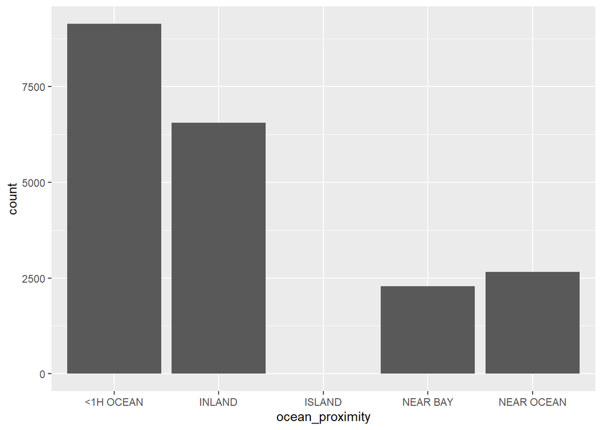

```r
housing %>%
  ggplot(aes(x= ocean_proximity)) +
  geom_bar()
```

In ocean_proximity column, there are 5 different categorical variables and we are going to turn these into booleans.

```r
categories = unique(housing$ocean_proximity)
# split the categories off
cat_housing = data.frame(ocean_proximity = housing$ocean_proximity)
```

```r
for(cat in categories){
  cat_housing[, cat] = rep(0, times = nrow(cat_housing))
}
head(cat_housing)
```

```
##   ocean_proximity NEAR BAY <1H OCEAN INLAND NEAR OCEAN ISLAND
## 1        NEAR BAY        0         0      0          0      0
## 2        NEAR BAY        0         0      0          0      0
## 3        NEAR BAY        0         0      0          0      0
## 4        NEAR BAY        0         0      0          0      0
## 5        NEAR BAY        0         0      0          0      0
## 6        NEAR BAY        0         0      0          0      0
```

```r
for(i in 1:length(cat_housing$ocean_proximity)){
    cat = as.character(cat_housing$ocean_proximity[i])
    cat_housing[,cat][i] = 1
}

head(cat_housing)
```

```
##   ocean_proximity NEAR BAY <1H OCEAN INLAND NEAR OCEAN ISLAND
## 1        NEAR BAY        1         0      0          0      0
## 2        NEAR BAY        1         0      0          0      0
## 3        NEAR BAY        1         0      0          0      0
## 4        NEAR BAY        1         0      0          0      0
## 5        NEAR BAY        1         0      0          0      0
## 6        NEAR BAY        1         0      0          0      0
```

```r
cat_columns = names(cat_housing)
keep_columns = cat_columns[cat_columns != 'ocean_proximity']
cat_housing = select(cat_housing,one_of(keep_columns))

tail(cat_housing)
```

```
##       NEAR BAY <1H OCEAN INLAND NEAR OCEAN ISLAND
## 20635        0         0      1          0      0
## 20636        0         0      1          0      0
## 20637        0         0      1          0      0
## 20638        0         0      1          0      0
## 20639        0         0      1          0      0
## 20640        0         0      1          0      0
```

## Scale the numerical variables

we are going to scale very one of the numericals except for ‘median_house_value’ which is the response varaible we will be working to predict. The x values are scaled so that the coefficients in things like support vector machines are given equal weight, but y value scale don’t affect the learning algorithms in the same way.

```r
drops = c('ocean_proximity','median_house_value')
housing_num =  housing[ , !(names(housing) %in% drops)]

head(housing_num)
```

```
## # A tibble: 6 x 8
##   longitude latitude housing_median_age population households median_income
##       <dbl>    <dbl>              <dbl>      <dbl>      <dbl>         <dbl>
## 1     -122.     37.9                 41        322        126          8.33
## 2     -122.     37.9                 21       2401       1138          8.30
## 3     -122.     37.8                 52        496        177          7.26
## 4     -122.     37.8                 52        558        219          5.64
## 5     -122.     37.8                 52        565        259          3.85
## 6     -122.     37.8                 52        413        193          4.04
## # ... with 2 more variables: mean_bedrooms <dbl>, mean_rooms <dbl>
```

```r
scaled_housing_num = scale(housing_num)

head(scaled_housing_num)
```

```
##      longitude latitude housing_median_age population households median_income
## [1,] -1.327803 1.052523          0.9821189 -0.9744050 -0.9770092    2.34470896
## [2,] -1.322812 1.043159         -0.6070042  0.8614180  1.6699206    2.33218146
## [3,] -1.332794 1.038478          1.8561366 -0.8207575 -0.8436165    1.78265622
## [4,] -1.337785 1.038478          1.8561366 -0.7660095 -0.7337637    0.93294491
## [5,] -1.337785 1.038478          1.8561366 -0.7598283 -0.6291419   -0.01288068
## [6,] -1.337785 1.038478          1.8561366 -0.8940491 -0.8017678    0.08744452
##      mean_bedrooms mean_rooms
## [1,]  -0.148510661  0.6285442
## [2,]  -0.248535936  0.3270334
## [3,]  -0.052900657  1.1555925
## [4,]  -0.053646030  0.1569623
## [5,]  -0.038194658  0.3447024
## [6,]   0.005232996 -0.2697231
```

## Merge the altered numerical and categorical dataframes and clean names

```r
cleaned_housing = cbind(cat_housing, scaled_housing_num, median_house_value=housing$median_house_value)

cleaned_housing <- cleaned_housing %>%
  clean_names()

head(cleaned_housing)
```

```
##   near_bay x1h_ocean inland near_ocean island longitude latitude
## 1        1         0      0          0      0 -1.327803 1.052523
## 2        1         0      0          0      0 -1.322812 1.043159
## 3        1         0      0          0      0 -1.332794 1.038478
## 4        1         0      0          0      0 -1.337785 1.038478
## 5        1         0      0          0      0 -1.337785 1.038478
## 6        1         0      0          0      0 -1.337785 1.038478
##   housing_median_age population households median_income mean_bedrooms
## 1          0.9821189 -0.9744050 -0.9770092    2.34470896  -0.148510661
## 2         -0.6070042  0.8614180  1.6699206    2.33218146  -0.248535936
## 3          1.8561366 -0.8207575 -0.8436165    1.78265622  -0.052900657
## 4          1.8561366 -0.7660095 -0.7337637    0.93294491  -0.053646030
## 5          1.8561366 -0.7598283 -0.6291419   -0.01288068  -0.038194658
## 6          1.8561366 -0.8940491 -0.8017678    0.08744452   0.005232996
##   mean_rooms median_house_value
## 1  0.6285442             452600
## 2  0.3270334             358500
## 3  1.1555925             352100
## 4  0.1569623             341300
## 5  0.3447024             342200
## 6 -0.2697231             269700
```

# Exploratory Data Analysis

After data cleaning, we are going to visualize the data for better understanding of the dataset.

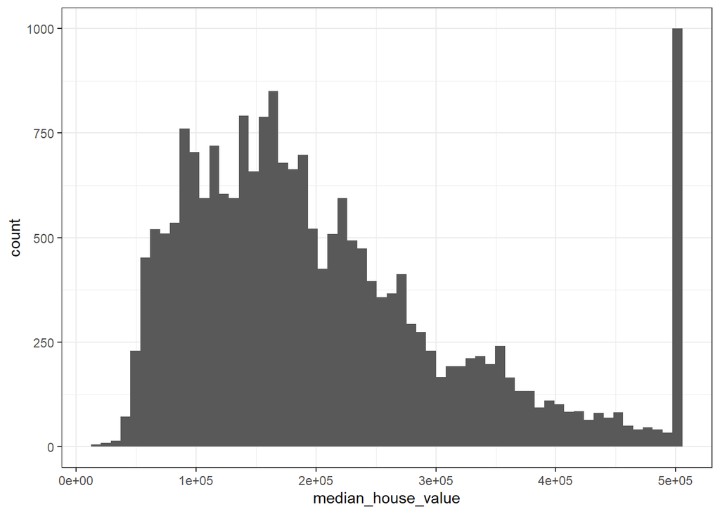

```r
cleaned_housing %>%
  ggplot(aes(x = median_house_value)) +
  geom_histogram(bins = 60) +
  theme_bw()
```

The distribution of median_house_value is right skewed and there exists an outlier.

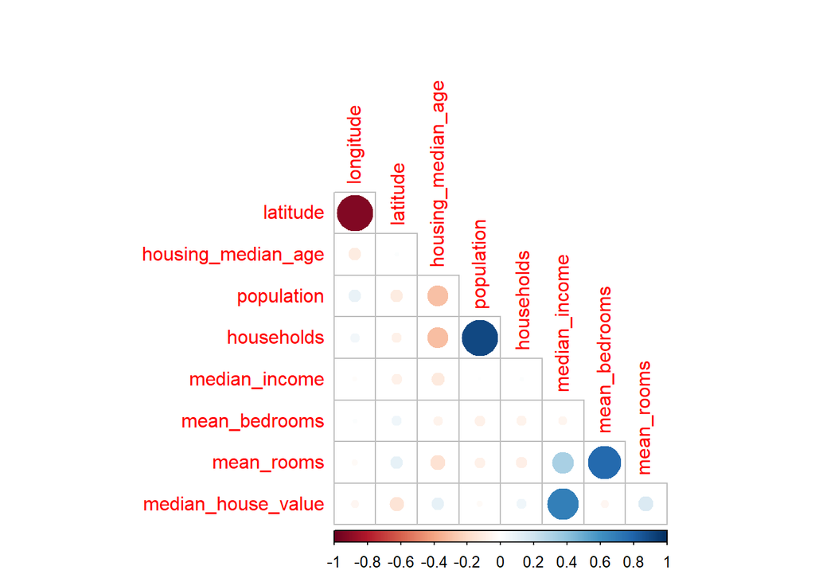

```r
cleaned_housing %>%
  select(-near_bay, -x1h_ocean, -inland, -near_ocean, -island) %>%
  cor(use = "complete.obs") %>%
  corrplot(type = "lower", diag = FALSE)
```

It appears that there is a strong negative correlation between latitude and longitude. Also, there are strong correlations between households-population, median_house_value-median_income, and mean_rooms-mean_bedrooms.

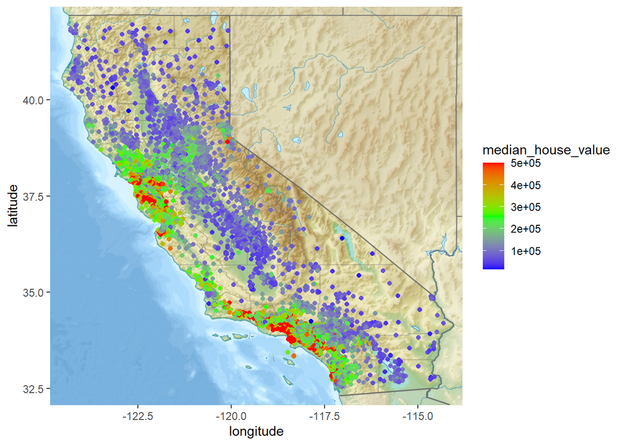

```r
california_image <- png::readPNG("Relief_map_of_California.png")

ggplot(housing, aes(x=longitude,y=latitude, col=median_house_value)) +
  annotation_custom(rasterGrob(california_image, width = unit(1,"npc"), height = unit(1,"npc")),-Inf, Inf, -Inf, Inf) +
  geom_point() + scale_color_gradientn(colours = c("blue","green","red"))
```

This shows how median_house_value is distributed all over California. It appears that there are houses concentrated near the seaside and they are likely to cost more than other houses that are farther from the seaside.

# Data Splitting

The data was split in a 80% training, 20% testing split. Stratified sampling was used as the median_house_value distribution was skewed.

```r
cleaned_housing_split <- cleaned_housing %>%
  initial_split(prop = 0.8, strata = "median_house_value")

cleaned_housing_train <- training(cleaned_housing_split)
cleaned_housing_test <- testing(cleaned_housing_split)

dim(cleaned_housing_train)
```

```
## [1] 16510    14
```

```r
dim(cleaned_housing_test)
```

```
## [1] 4130   14
```

The training set has about 16500+ observations and the testing data has about 4100+ observations.

```r
cleaned_housing_recipe <- recipe(median_house_value ~ ., data = cleaned_housing_train) %>%
  step_dummy(all_nominal_predictors()) %>%
  step_normalize(all_predictors())
```

```r
cleaned_housing_fold <- vfold_cv(cleaned_housing_train, v = 5, strata = median_house_value)
```

Since the response variable median_house_value is continuous variable, we are going to use regression models rather than classification models. First, we are going to introduce a KNN model.

## KNN model

```r
knn_model <-
  nearest_neighbor(
    neighbors = tune(),
    mode = "regression") %>%
  set_engine("kknn")

knn_workflow <- workflow() %>%
  add_model(knn_model) %>%
  add_recipe(cleaned_housing_recipe)
```

KNN model could be used for both regression and classification model but here, we are going to set the mode as “regression” since the response variable is not categorical.

```r
cleaned_housing_grid <- tibble(neighbors=seq(from=1, to=10, by=2))

cleaned_housing_results <- knn_workflow%>%
    tune_grid(resamples=cleaned_housing_fold, grid=cleaned_housing_grid)
```

In order to get a minimal RMSE(Root Mean Square Error), we are going to make a tibble of values from 1 to 10, incrementing by 2, for all the models except for SVM model.

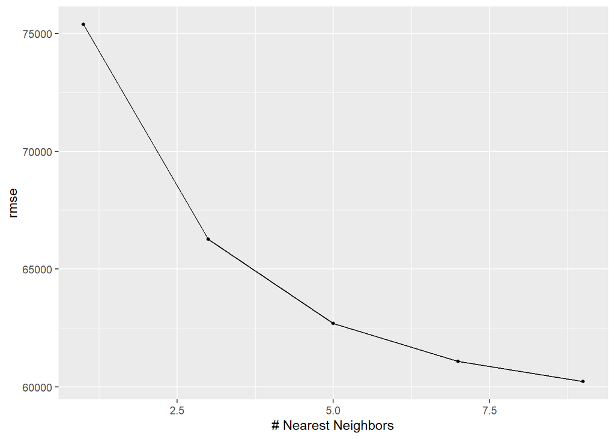

```r
autoplot(cleaned_housing_results, metric = "rmse")
```

```r
show_best(cleaned_housing_results, metric = "rmse")
```

```
## # A tibble: 5 x 7
##   neighbors .metric .estimator   mean     n std_err .config
##       <dbl> <chr>   <chr>       <dbl> <int>   <dbl> <chr>
## 1         9 rmse    standard   60219.     5    608. Preprocessor1_Model5
## 2         7 rmse    standard   61080.     5    637. Preprocessor1_Model4
## 3         5 rmse    standard   62701.     5    687. Preprocessor1_Model3
## 4         3 rmse    standard   66264.     5    804. Preprocessor1_Model2
## 5         1 rmse    standard   75385.     5   1075. Preprocessor1_Model1
```

Down below, we are going to add cleaned_housing_fit to the workflow where we added KNN model and recipe, and fit the model into cleaned_housing_train. The cleaned_housing_summary stores the result of predicting cleaned_housing_test and metrics.

```r
cleaned_housing_spec <- nearest_neighbor(weight_func="rectangular", neighbors=3) %>%
    set_engine("kknn")%>%
    set_mode("regression")
cleaned_housing_fit <- workflow() %>%
    add_recipe(cleaned_housing_recipe) %>%
    add_model(cleaned_housing_spec)%>%
    fit(data=cleaned_housing_train)
cleaned_housing_summary <- cleaned_housing_fit %>%
    predict(cleaned_housing_test) %>%
    bind_cols(cleaned_housing_test) %>%
    metrics(truth=median_house_value, estimate=.pred) %>%
    filter(.metric=="rmse")
cleaned_housing_summary
```

```
## # A tibble: 1 x 3
##   .metric .estimator .estimate
##   <chr>   <chr>          <dbl>
## 1 rmse    standard      62986.
```

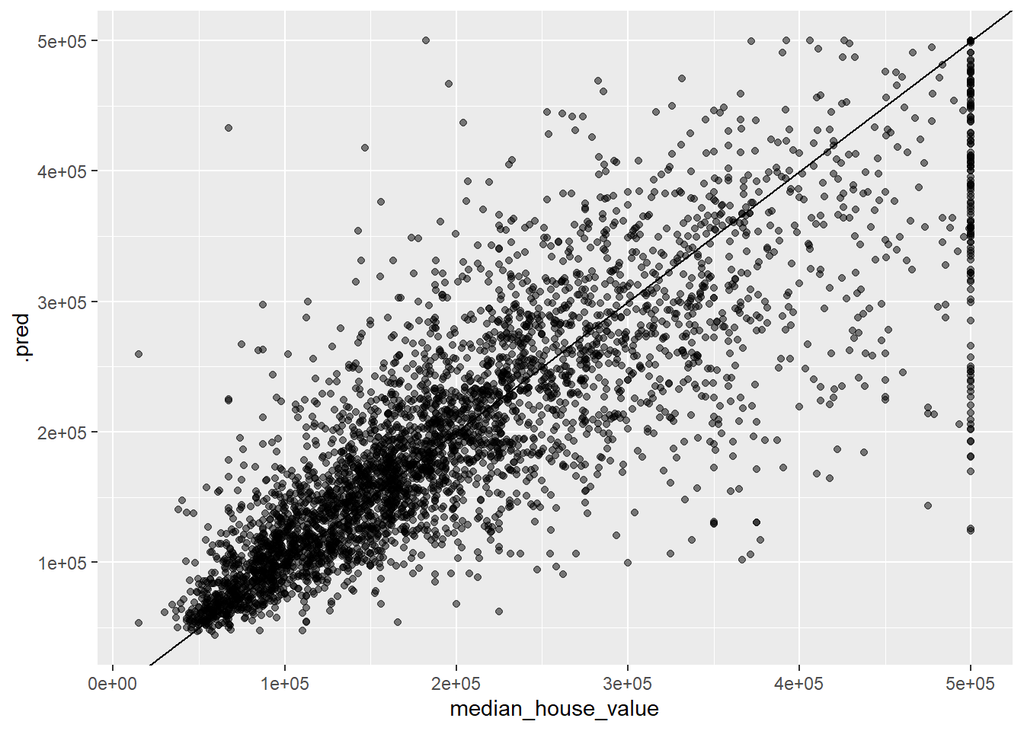

```r
augment(cleaned_housing_fit, new_data = cleaned_housing_test) %>%
  ggplot(aes(median_house_value, .pred)) +
  geom_abline() +
  geom_point(alpha = 0.5)
```

```r
svm_model <-
  svm_poly(
    cost = tune(),
    mode = "regression") %>%
  set_engine("kernlab")
```

```r
svm_workflow <- workflow() %>%
  add_model(svm_model) %>%
  add_recipe(cleaned_housing_recipe)
```

```r
cleaned_housing_grid_svm <- grid_regular(cost(range = c(-3, -1)), levels = 10)

cleaned_housing_results_svm <- svm_workflow %>%
    tune_grid(resamples=cleaned_housing_fold, grid=cleaned_housing_grid_svm)
```

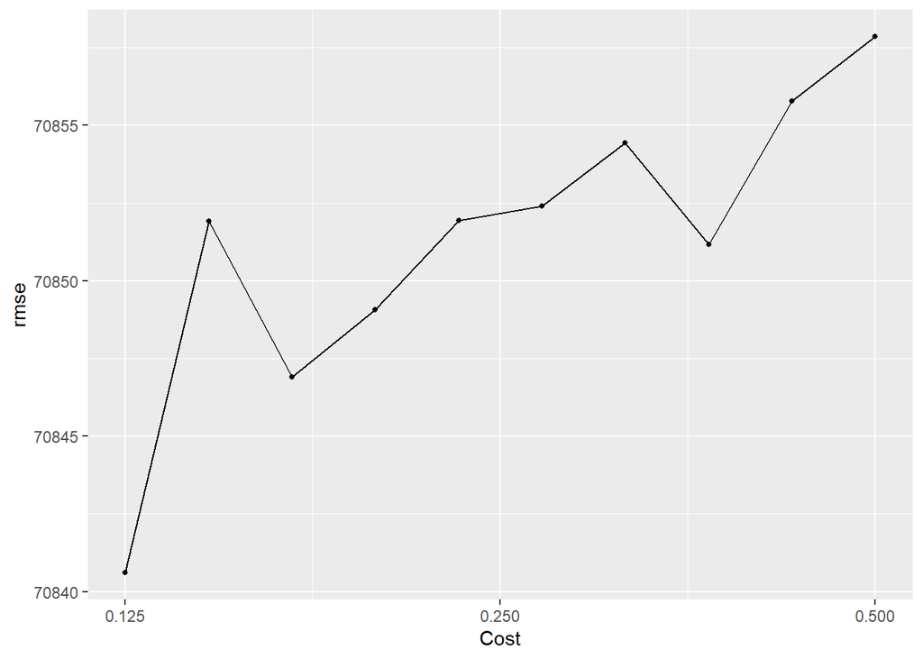

```r
autoplot(cleaned_housing_results_svm, metric = "rmse")
```

```r
show_best(cleaned_housing_results_svm, metric = "rmse")
```

```
## # A tibble: 5 x 7
##    cost .metric .estimator   mean     n std_err .config
##   <dbl> <chr>   <chr>       <dbl> <int>   <dbl> <chr>
## 1 0.125 rmse    standard   70841.     5    907. Preprocessor1_Model01
## 2 0.170 rmse    standard   70847.     5    911. Preprocessor1_Model03
## 3 0.198 rmse    standard   70849.     5    914. Preprocessor1_Model04
## 4 0.367 rmse    standard   70851.     5    916. Preprocessor1_Model08
## 5 0.146 rmse    standard   70852.     5    914. Preprocessor1_Model02
```

```r
cleaned_housing_spec_svm <- svm_poly(cost=0.1984251) %>%
    set_engine("kernlab")%>%
    set_mode("regression")
cleaned_housing_fit_svm <- workflow() %>%
    add_recipe(cleaned_housing_recipe) %>%
    add_model(cleaned_housing_spec_svm)%>%
    fit(data=cleaned_housing_train)
cleaned_housing_summary_svm <- cleaned_housing_fit_svm %>%
    predict(cleaned_housing_test) %>%
    bind_cols(cleaned_housing_test) %>%
    metrics(truth= median_house_value, estimate=.pred) %>%
    filter(.metric=="rmse")
cleaned_housing_summary_svm
```

```
## # A tibble: 1 x 3
##   .metric .estimator .estimate
##   <chr>   <chr>          <dbl>
## 1 rmse    standard      68790.
```

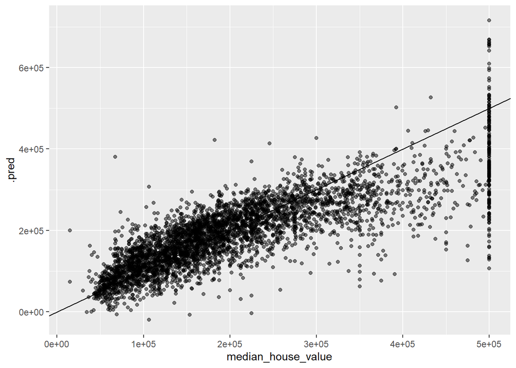

```r
augment(cleaned_housing_fit_svm, new_data = cleaned_housing_test) %>%
  ggplot(aes(median_house_value, .pred)) +
  geom_abline() +
  geom_point(alpha = 0.5)
```

# Random Forest Model

```r
rf_model <-
  rand_forest(
    mtry = tune(),
    mode = "regression") %>%
  set_engine("ranger")

rf_workflow <- workflow() %>%
  add_model(rf_model) %>%
  add_recipe(cleaned_housing_recipe)
```

```r
cleaned_housing_grid_rf <- tibble(mtry=seq(from=1, to=10, by=2))

cleaned_housing_results_rf <- rf_workflow %>%
    tune_grid(resamples= cleaned_housing_fold, grid= cleaned_housing_grid_rf)
```

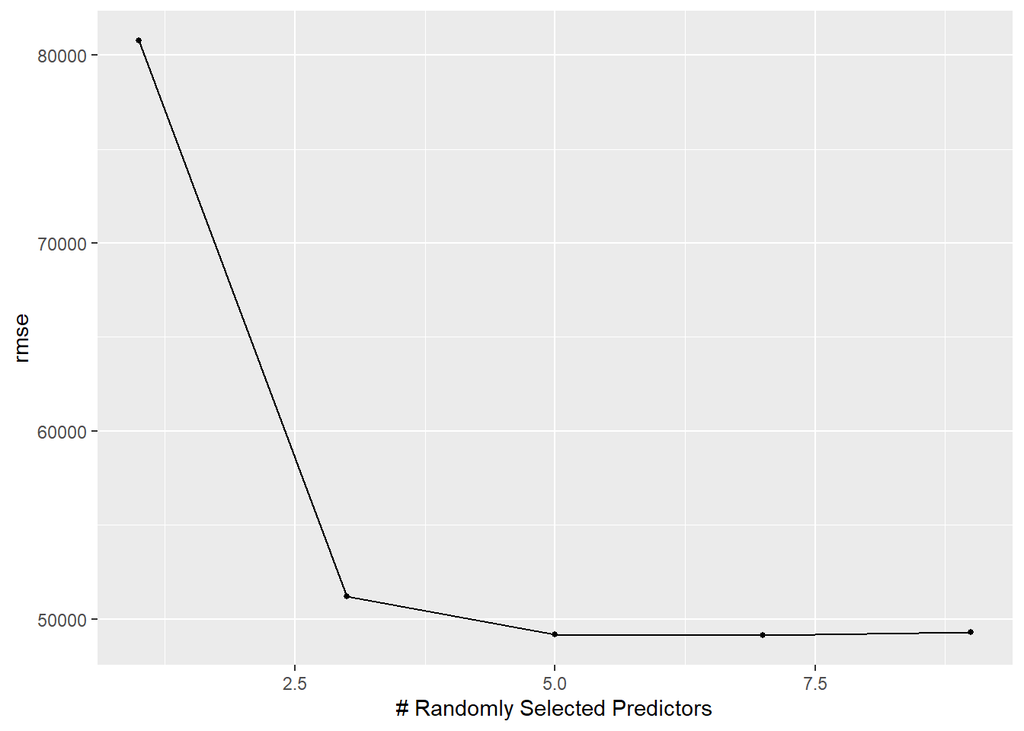

```r
autoplot(cleaned_housing_results_rf, metric = "rmse")
```

```r
show_best(cleaned_housing_results_rf, metric = "rmse")
```

```
## # A tibble: 5 x 7
##    mtry .metric .estimator   mean     n std_err .config
##   <dbl> <chr>   <chr>       <dbl> <int>   <dbl> <chr>
## 1     7 rmse    standard   49114.     5    369. Preprocessor1_Model4
## 2     5 rmse    standard   49159.     5    293. Preprocessor1_Model3
## 3     9 rmse    standard   49274.     5    393. Preprocessor1_Model5
## 4     3 rmse    standard   51179.     5    419. Preprocessor1_Model2
## 5     1 rmse    standard   80771.     5    459. Preprocessor1_Model1
```

According to the cart and graph above, we can tell the lowest rmse occurs when mtry value is equal to 7.

```r
cleaned_housing_spec_rf <- rand_forest(mtry=7) %>%
    set_engine("ranger")%>%
    set_mode("regression")
cleaned_housing_fit_rf <- workflow() %>%
    add_recipe(cleaned_housing_recipe) %>%
    add_model(cleaned_housing_spec_rf)%>%
    fit(data=cleaned_housing_train)
cleaned_housing_summary_rf <- cleaned_housing_fit_rf %>%
    predict(cleaned_housing_test) %>%
    bind_cols(cleaned_housing_test) %>%
    metrics(truth=median_house_value, estimate=.pred) %>%
    filter(.metric=="rmse")
cleaned_housing_summary_rf
```

```
## # A tibble: 1 x 3
##   .metric .estimator .estimate
##   <chr>   <chr>          <dbl>
## 1 rmse    standard      48738.
```

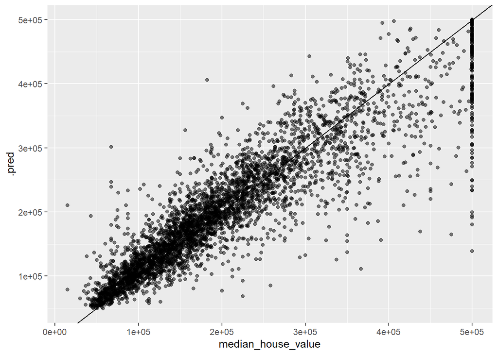

```r
augment(cleaned_housing_fit_rf, new_data = cleaned_housing_test) %>%
  ggplot(aes(median_house_value, .pred)) +
  geom_abline() +
  geom_point(alpha = 0.5)
```

# Boost Tree Model

```r
bt_model <-
  boost_tree(
    mtry = tune(),
    mode = "regression") %>%
  set_engine("xgboost")

bt_workflow <- workflow() %>%
  add_model(bt_model) %>%
  add_recipe(cleaned_housing_recipe)
```

```r
cleaned_housing_grid_bt <- tibble(mtry=seq(from=1, to=10, by=2))

cleaned_housing_results_bt <- bt_workflow %>%
    tune_grid(resamples=cleaned_housing_fold, grid=cleaned_housing_grid_bt)
```

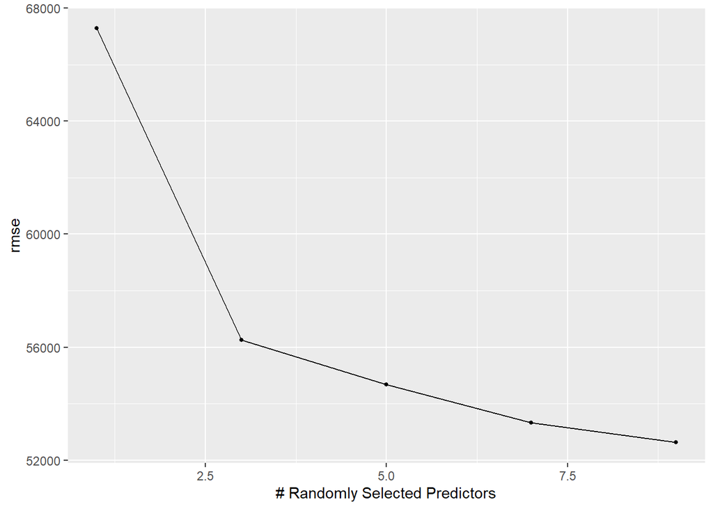

```r
autoplot(cleaned_housing_results_bt, metric = "rmse")
```

```r
show_best(cleaned_housing_results_bt, metric = "rmse")
```

```
## # A tibble: 5 x 7
##    mtry .metric .estimator   mean     n std_err .config
##   <dbl> <chr>   <chr>       <dbl> <int>   <dbl> <chr>
## 1     9 rmse    standard   52629.     5    192. Preprocessor1_Model5
## 2     7 rmse    standard   53338.     5    376. Preprocessor1_Model4
## 3     5 rmse    standard   54688.     5    523. Preprocessor1_Model3
## 4     3 rmse    standard   56262.     5    383. Preprocessor1_Model2
## 5     1 rmse    standard   67282.     5    821. Preprocessor1_Model1
```

According to both of the chart and the graph above, we could say the lowest rmse occurs when mtry values is equal to 9.

```r
cleaned_housing_spec_bt <- boost_tree(mtry=7) %>%
    set_engine("xgboost")%>%
    set_mode("regression")
cleaned_housing_fit_bt <- workflow() %>%
    add_recipe(cleaned_housing_recipe) %>%
    add_model(cleaned_housing_spec_bt)%>%
    fit(data=cleaned_housing_train)
cleaned_housing_summary_bt <- cleaned_housing_fit_bt %>%
    predict(cleaned_housing_test) %>%
    bind_cols(cleaned_housing_test) %>%
    metrics(truth=median_house_value, estimate=.pred) %>%
    filter(.metric=="rmse")
cleaned_housing_summary_bt
```

```
## # A tibble: 1 x 3
##   .metric .estimator .estimate
##   <chr>   <chr>          <dbl>
## 1 rmse    standard      53618.
```

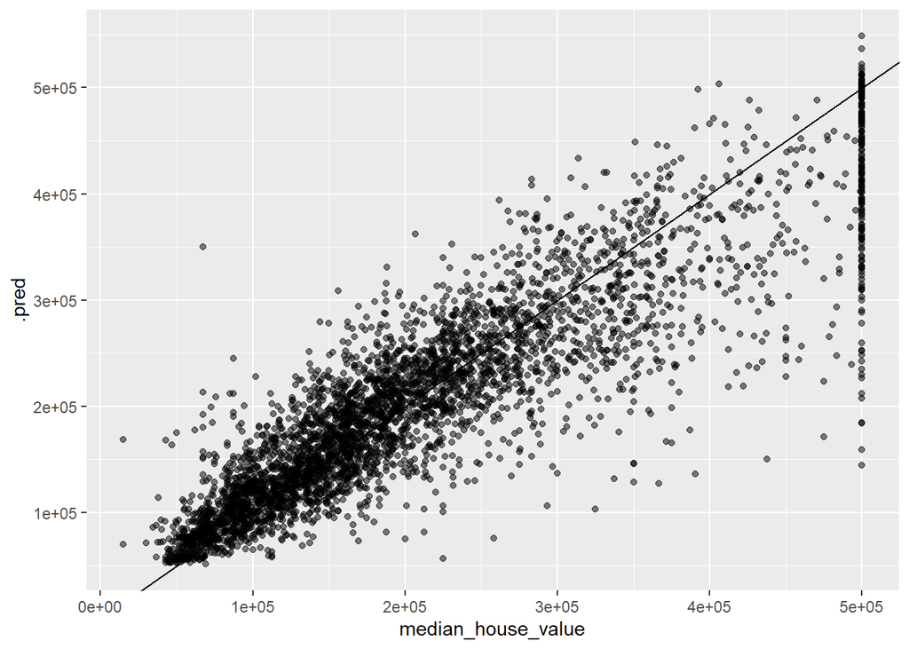

```r
augment(cleaned_housing_fit_bt, new_data = cleaned_housing_test) %>%
  ggplot(aes(median_house_value, .pred)) +
  geom_abline() +
  geom_point(alpha = 0.5)
```

# Conclusion

```r
Model <- c('K-nearest neighbors', 'Support Vector Machine', 'Random Forest', 'Boost Tree')
cleaned_housing_summary <- select_if(cleaned_housing_summary, is.numeric)
cleaned_housing_summary_svm <- select_if(cleaned_housing_summary_svm, is.numeric)
cleaned_housing_summary_rf <- select_if(cleaned_housing_summary_rf, is.numeric)
cleaned_housing_summary_bt <- select_if(cleaned_housing_summary_bt, is.numeric)
RMSE <- c(cleaned_housing_summary, cleaned_housing_summary_svm, cleaned_housing_summary_rf, cleaned_housing_summary_bt)
RMSE_value <- as.numeric(RMSE)

Table <- data.frame(Model,RMSE_value)
Table
```

```
##                    Model RMSE_value
## 1    K-nearest neighbors   62985.93
## 2 Support Vector Machine   68789.71
## 3          Random Forest   48737.59
## 4             Boost Tree   53618.39
```